# **Executive Summary**

## Shift to More of a Passing Game

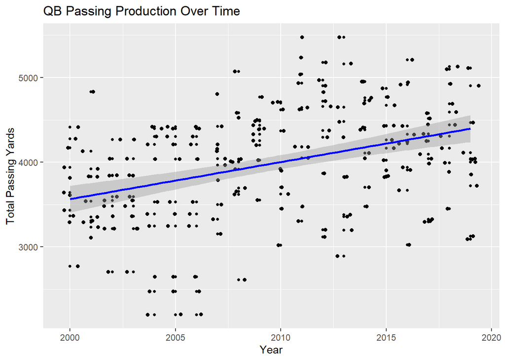

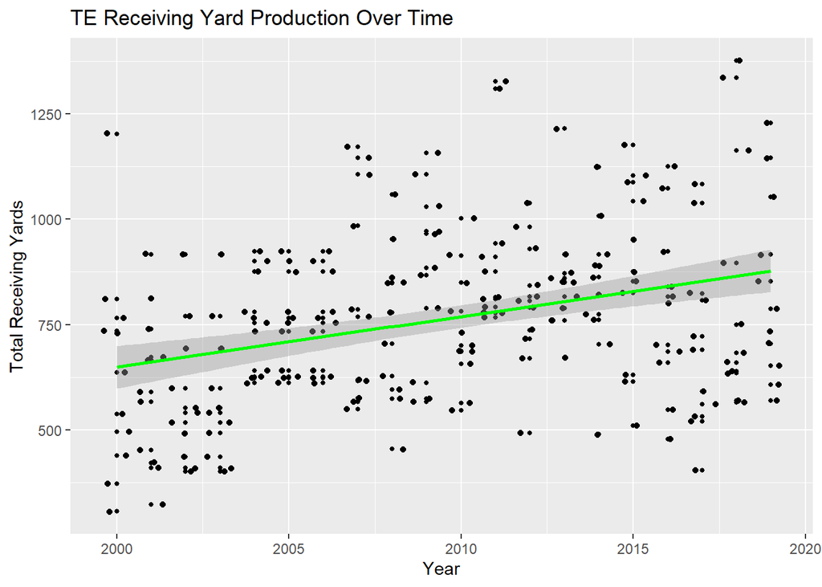

When first analyzing the fantasy production of QBs over the last 20 years, it was clear to me that there was an upward trend. This led to a second interesting finding: QBs are passing more and are utilizing their TEs more in the offense. This was evident in the above scatterplots and linear models highlighting the increase in passing yards for QBs with the increase of receiving yards for TEs. This is important because it tells us more about how the playing style of the NFL has shifted to a passing game and how the QB has become more crucial for leading an offensive. This tells us that perhaps receivers, in general, are becoming more valuable as well. We are seeing this at the TE position especially, which brings me to my last critical finding.